# Simple Linear Regression Tutorial

Simon Hans Edasi

2023-06-07

### Sections 5.4 and 5.5

## Simple linear regression

NOTE TO STUDENTS: In any r chunk you write a ggplot command, please replace the typical {r} (I omitted the ``` intentionally) with {r, warning=FALSE, results=‘hide’,message=FALSE}. This is already done in a few places so as an alternative you can just write your ggplot command there.

Create the new script

```r
# Clear the memory

rm(list=ls())

# Load libraries


library(ggplot2)
library(dplyr)
library(ggfortify)
library(datasets)
library(datasets.load)
library(readr)
library(gridExtra)
# Load the data set plant.growth.rate.csv

plant_gr <- read.csv('plant.growth.rate.csv')
```

Plot the data in a scatterplot

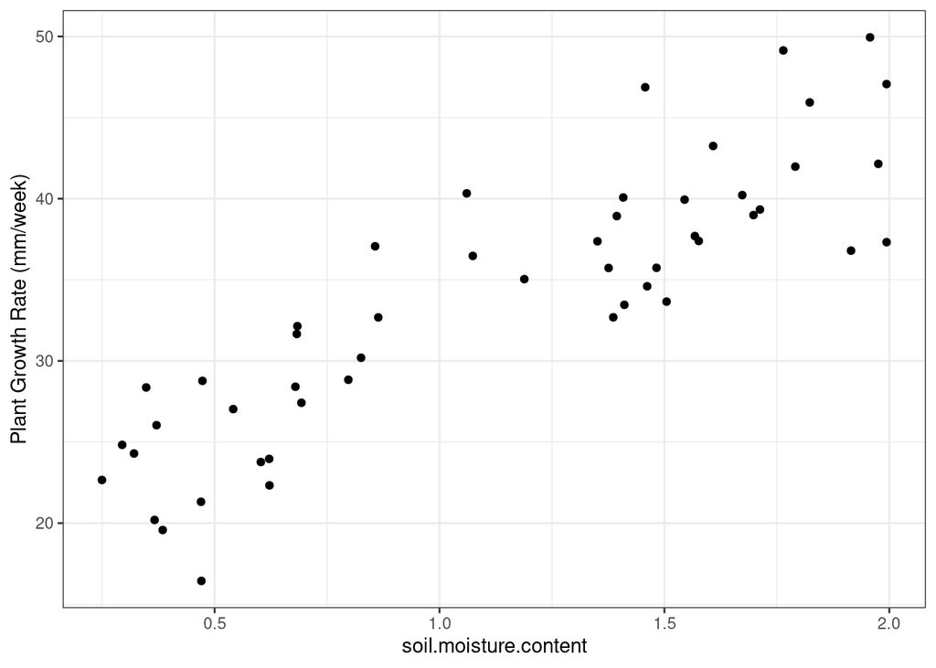

```r
ggplot(plant_gr,
  aes(x = soil.moisture.content, y = plant.growth.rate)) +
  geom_point() +
  ylab("Plant Growth Rate (mm/week)") +
  theme_bw()
```

Fit a simple linear regression model to the data and estimate its slope and intercept parameters.

In other words, we will fit a linear model, where we hypothesize that plant growth rate is a function of soil moisture content, using the variables from the plant_gr data frame. Save the results as an object for later use.

```r
   #Estimate fitted linear regression model
model_pgr <- lm(plant.growth.rate ~ soil.moisture.content,
data = plant_gr)
sms <- plant_gr$soil.moisture.content
pgr <- plant_gr$plant.growth.rate

model_pgr <- lm(pgr ~ sms, data = plant_gr)
# Print the estimates of the regression coefficients,
# i.e., the estimated intercept and slope.
model_pgr
```

```
##
## Call:
## lm(formula = pgr ~ sms, data = plant_gr)
##
## Coefficients:
## (Intercept)          sms
##       19.35        12.75
```

Using the results above, let’s write the estimated linear model relationship between plant growth and soil moisture content in words:

Plant Growth = 12.75 * Soil Moisture + 19.35

Check the assumptions of the linear regression model. Do this by visually examining them using the “autoplot()” function in the package “ggfortify”.

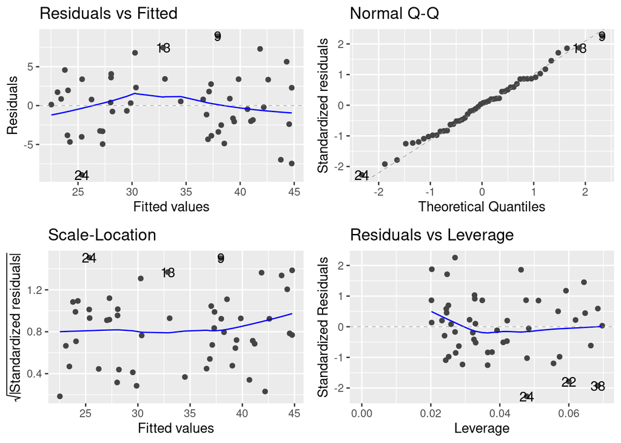

```r
library(ggfortify)
autoplot(model_pgr)
```

All of these plots are based around the residuals-errors around regression line.

```
The interpretation of these plots is (from BC&P):
```

[1] Top left. This panel is about the ‘systematic part’ of the model; it tells us whether a line is appropriate to fit to the data. If things have gone wrong, hump-shapes or valleys will be apparent. These would mean that the structure of your model was wrong. For example, fitting a straight line didn’t work. Lots of people suggest you look at this to evaluate the assumption of equal variance-homo- vs heteroskedasticity (unequal variances). But there is a better plot (bottom left) for this.

[2] Top right. This QQ Plot evaluates the assumption of normality of the residuals. The dots are the residuals, and the dashed line the expectation under the normal distribution. This is a much better tool than making a histogram of the residuals, especially with small sample sizes like less than 100.

[3] Bottom left. This evaluates the assumption of equal variance. The y-axis is a standardized (all positive) indicator of the variation. Linear models assume that the variance is constant over all predicted values of the response variable. There should be no pattern. But there might be one if, for example, the variance increases with the mean, as it might with count data (see Chapter 7).

[4] Bottom right. This evaluates leverage, a tool not only to detect influential data points, ones that move the gradient more than might be expected, but also to detect outliers.

## Conclusion from a review of the plots:

As BC&P state, Overall, the take-home message from this example, and these plots, is that everything is just fine. There is no pattern in either of the left-hand plots. The normal-distribution assumption is clearly met. And there are no points exerting high influence.

Now we will test the null hypothesis that soil moisture has no effect on plant growth, i.e., the slope coefficient = 0. In doing this, we will assess the real estimate of plant growth at zero soil moisture (the intercept) and the change of growth rate with soil moisture (the gradient/slope). We do all of this using two tools, tools we will use for every general (and generalized) linear model from here on in and out: anova() and summary().

The adjusted R-squared is a penalization of the calculated R-squared for the number of predictors (variables) added to the model. In general, as the number of predictors is increased in a linear model the R-squared will be greater than that of a linear that assumes fewer predictors. This is true because the larger model(the model with more predictor variables) will contain the original predictors and the additional predictors will add to the amount of variation in the data that the estimated model explains.

The function summary() produces a table of the estimates of the coefficients of the line that is ‘the model’: an intercept and a slope.

Produce the ANOVA table using the object we created from estimating the coefficients of the linear regression model.

Linear regression uses ordinary least squares to minimize the sum of squares (SS) to estimate the coefficients (parameters) in the linear model. If we rearrange the SS, apply some algebra, and recognize that the cross-product SS term equals zero, we arrive at a rearranged equation that states:

Total SS = Regression SS + Error SS.

We can now use ANOVA to analyze the sources of the Total SS. Hence, regression and ANOVA are intimately linked. ANOVA will provide a frame- work for testing hypotheses in linear models.

The ANOVA table is a classic assessment of the null hypothesis, that there is no relationship between soil moisture content and plant growth. It presents the F-value, degrees of freedom, and the p-value associated with the explanatory variables in the model (in this case, the model has one explanatory variable, i.e., soil moisture content).

The ANOVA table shows a rather large F-value, indicating that the error variance is small relative to the variance attributed to the explanatory variable. This, with the single degree of freedom, leads to the tiny p-value.

```r
(anova(model_pgr))
```

```
## Analysis of Variance Table
##
## Response: pgr
##           Df  Sum Sq Mean Sq F value    Pr(>F)
## sms        1 2521.15 2521.15  156.08 < 2.2e-16 ***
## Residuals 48  775.35   16.15
## ---
## Signif. codes:  0 '***' 0.001 '**' 0.01 '*' 0.05 '.' 0.1 ' ' 1
```

Calculate and display the summary( table) that provides the regression analysis.

```r
summary(model_pgr)
```

```
##
## Call:
## lm(formula = pgr ~ sms, data = plant_gr)
##
## Residuals:
##     Min      1Q  Median      3Q     Max
## -8.9089 -3.0747  0.2261  2.6567  8.9406
##
## Coefficients:
##             Estimate Std. Error t value Pr(>|t|)
## (Intercept)   19.348      1.283   15.08   <2e-16 ***
## sms           12.750      1.021   12.49   <2e-16 ***
## ---
## Signif. codes:  0 '***' 0.001 '**' 0.01 '*' 0.05 '.' 0.1 ' ' 1
##
## Residual standard error: 4.019 on 48 degrees of freedom
## Multiple R-squared:  0.7648, Adjusted R-squared:  0.7599
## F-statistic: 156.1 on 1 and 48 DF,  p-value: < 2.2e-16
```

Show our estimated model together with the original data and 95% confidence intervals.

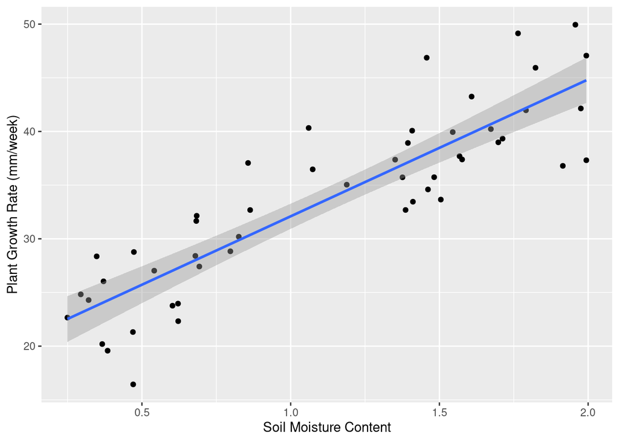

```r
ggplot(plant_gr, aes(x = soil.moisture.content,
y = plant.growth.rate)) +
geom_point() +
geom_smooth(method = 'lm') +
ylab("Plant Growth Rate (mm/week)") +
xlab("Soil Moisture Content")
```

```r
theme_bw()
```

Calculate 95% confidence and prediction intervals. Plot the results.

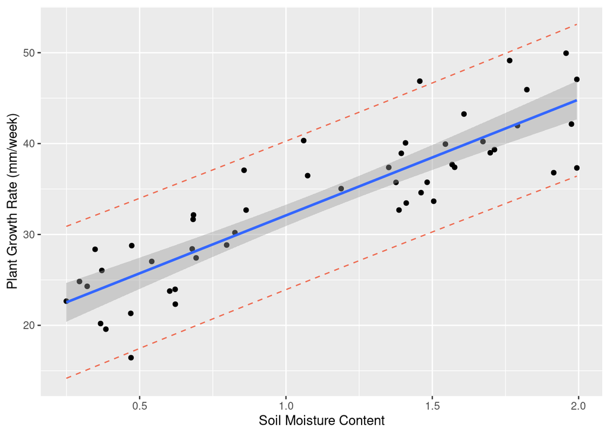

```r
sms.new <- data.frame(seq(0,20,.401) / 10)

pred <- data.frame(predict(model_pgr, newdata = sms.new, interval = 'prediction'))

intervals <- data.frame(predict(model_pgr, newdata = sms.new, interval = 'confidence'))

all_data <- cbind(plant_gr, intervals)

ggplot(all_data, aes(x = sms,
y = pgr)) +
geom_point() +
geom_smooth(method = 'lm') +
geom_line(aes(y = pred$lwr), col = "coral2", linetype = "dashed") +
geom_line(aes(y = pred$upr), col = "coral2", linetype = "dashed") +
ylab("Plant Growth Rate (mm/week)") +
xlab("Soil Moisture Content")
```

```r
theme_bw()
```

[output not shown]

[output cut: 369 more lines]

[output not shown]

Compute fitted model output and upper (upr) and lower (lwr) prediction intervals

```r
pred <- data.frame(predict(model_pgr, newdata = sms.new, interval = 'prediction'))
pred
```

```
##         fit      lwr      upr
## 1  25.33676 17.06460 33.60891
## 2  26.24992 18.00046 34.49937
## 3  40.99706 32.75216 49.24197
## 4  29.87422 21.68942 38.05902
## 5  30.27248 22.09228 38.45268
## 6  39.85278 31.63201 48.07355
## 7  22.52979 14.17204 30.88754
## 8  40.67913 32.44134 48.91692
## 9  37.92819 29.73882 46.11756
## 10 25.37839 17.10732 33.64945
## 11 39.04386 30.83769 47.25002
## 12 39.33595 31.12474 47.54715
## 13 32.86932 24.70683 41.03182
## 14 41.84226 33.57695 50.10758
```

[output cut: 36 more lines]

Combine the upper and lower prediction intervals with the original data

```r
all_data <- cbind(plant_gr, pred)
all_data
```

Check for what information is available for use from the linear model fitting.

```r
summary(model_pgr)
```

```
##
## Call:
## lm(formula = pgr ~ sms, data = plant_gr)
##
## Residuals:
##     Min      1Q  Median      3Q     Max
## -8.9089 -3.0747  0.2261  2.6567  8.9406
##
## Coefficients:
##             Estimate Std. Error t value Pr(>|t|)
## (Intercept)   19.348      1.283   15.08   <2e-16 ***
## sms           12.750      1.021   12.49   <2e-16 ***
## ---
## Signif. codes:  0 '***' 0.001 '**' 0.01 '*' 0.05 '.' 0.1 ' ' 1
##
## Residual standard error: 4.019 on 48 degrees of freedom
## Multiple R-squared:  0.7648, Adjusted R-squared:  0.7599
## F-statistic: 156.1 on 1 and 48 DF,  p-value: < 2.2e-16
```

Display the estimated coefficients in the linear model.

```r
model_pgr
```

```
##
## Call:
## lm(formula = pgr ~ sms, data = plant_gr)
##
## Coefficients:
## (Intercept)          sms
##       19.35        12.75
```

```r
?cbind
all_data
```

```
##    soil.moisture.content plant.growth.rate      fit      lwr      upr
## 1              0.4696876          21.31695 25.33676 17.06460 33.60891
## 2              0.5413106          27.03072 26.24992 18.00046 34.49937
## 3              1.6979915          38.98937 40.99706 32.75216 49.24197
## 4              0.8255799          30.19529 29.87422 21.68942 38.05902
## 5              0.8568173          37.06547 30.27248 22.09228 38.45268
## 6              1.6082405          43.24982 39.85278 31.63201 48.07355
## 7              0.2495252          22.66094 22.52979 14.17204 30.88754
## 8              1.6730545          40.22102 40.67913 32.44134 48.91692
## 9              1.4572865          46.86880 37.92819 29.73882 46.11756
## 10             0.4729527          28.77176 25.37839 17.10732 33.64945
## 11             1.5447931          39.94184 39.04386 30.83769 47.25002
## 12             1.5677030          37.69565 39.33595 31.12474 47.54715
## 13             1.0604983          40.32792 32.86932 24.70683 41.03182
## 14             1.7642840          49.13783 41.84226 33.57695 50.10758
```

[output cut: 36 more lines]

Display the plant growth rates estimated by the linear regression model.

```r
pred
```

```
##         fit      lwr      upr
## 1  25.33676 17.06460 33.60891
## 2  26.24992 18.00046 34.49937
## 3  40.99706 32.75216 49.24197
## 4  29.87422 21.68942 38.05902
## 5  30.27248 22.09228 38.45268
## 6  39.85278 31.63201 48.07355
## 7  22.52979 14.17204 30.88754
## 8  40.67913 32.44134 48.91692
## 9  37.92819 29.73882 46.11756
## 10 25.37839 17.10732 33.64945
## 11 39.04386 30.83769 47.25002
## 12 39.33595 31.12474 47.54715
## 13 32.86932 24.70683 41.03182
## 14 41.84226 33.57695 50.10758
```

[output cut: 36 more lines]

End of the Simple Linear Regression Tutorial!!